# Project (Assignment 9)

### UNEMPLOYMENT AND CORRELATED INDICATORS - Comparison among BRIC countries

Subject: Programming for Data Analytics

Name: Rachel Fanti Coelho Lima

Data: jan/2020

## Libraries

```python
%matplotlib inline
import matplotlib.pyplot as plt
from matplotlib.ticker import FormatStrFormatter
import numpy as np
import pandas as pd
from pandas.plotting import scatter_matrix # Functions used to view scatter plots
import seaborn as sns
from math import ceil
```

```python
from sklearn.feature_selection import SelectKBest, f_regression
from sklearn.model_selection import train_test_split
from sklearn.preprocessing import PolynomialFeatures
from sklearn.linear_model import LinearRegression
from sklearn.pipeline import make_pipeline
from sklearn.model_selection import GridSearchCV
# Functions used to do polinomial regressions

from sklearn.metrics import mean_squared_error, r2_score # Functions used to evaluate models
```

## Reading and processing the data

```python
# Reading the files
# Checking separators, head, nan data (blank) and rows to skip,
# Checking number of total rows (similar to the CSV file)
# Verifying df.head(), df.tail(), df.info(), df.describe()

df_pub = pd.read_csv('./data/PublicSector_Indicators.csv', sep = ";") # skiprows= range(81496,81501)
df_eco = pd.read_csv('./data/Economy_Data.csv', sep = ";")
df_edu = pd.read_csv('./data/EducationAndEnviron_Data.csv', sep = ";")
df_pov = pd.read_csv('./data/HealthAndPoverty_Data.csv', sep = ";")
df_fields = pd.read_csv('./data/FieldsSelected.csv', sep = ";")
```

```python
# Uniting the datasets
# Checking number of total rows (sum of each data frame)
# We will observe if there are duplicated data in the consolidated database ahead,
# when we group_by Indicator, Country and Year

df_aux = pd.concat([df_pub, df_eco , df_edu, df_pov])

# Inner joinning the datasets to select only the fields that will be used in the project
# Checking the number of total rows
# Checking to see if all series were recognized (same number of df_fields rows)
# print(len(set(df_aux['SeriesName']))) = print(len(set(df_aux['Indicator']))) = len(df_fields)
# identify indicator (if not recognized): set(df_fields.SeriesName).difference(df_aux.SeriesName)

df_aux = pd.merge(df_aux, df_fields, on='SeriesName', validate='m:1')
df_aux.head()
```

|  | SeriesName | SeriesCode | CountryName | CountryCode | Year | Value | Indicator | Dataset | Series | Unit | Regression |
| --- | --- | --- | --- | --- | --- | --- | --- | --- | --- | --- | --- |
| 0 | Children in employment, total (% of children a... | SL.TLF.0714.ZS | Brazil | BRA | 1970.0 | NaN | emp_child | Employment | Children in employment | (% of children ages 7-14) | yes |
| 1 | Children in employment, total (% of children a... | SL.TLF.0714.ZS | China | CHN | 1970.0 | NaN | emp_child | Employment | Children in employment | (% of children ages 7-14) | yes |
| 2 | Children in employment, total (% of children a... | SL.TLF.0714.ZS | India | IND | 1970.0 | NaN | emp_child | Employment | Children in employment | (% of children ages 7-14) | yes |
| 3 | Children in employment, total (% of children a... | SL.TLF.0714.ZS | Russian Federation | RUS | 1970.0 | NaN | emp_child | Employment | Children in employment | (% of children ages 7-14) | yes |
| 4 | Children in employment, total (% of children a... | SL.TLF.0714.ZS | South Africa | ZAF | 1970.0 | NaN | emp_child | Employment | Children in employment | (% of children ages 7-14) | yes |

```python
## Transforming "Indicator" rows into columns, simplifying the table
# Droping columns "SeriesName", "SeriesCode", "Series", "Unit", "CountryName"
# Checking if the number of columns is similar to the number of indicators and if the number of rows makes sense
                    # (df_aux x df)
                    # Number of rows (13750:53 = 259 <> 250)!
                    # Sum of total values (df_aux['Value'].sum() = 265,884,923,397,156.12 <>
                    #                      df.loc[:,'agr':'unemp'].sum().sum() = 265,884,923,395,117.03)!

# Verifying duplicate indicators that are in df_Aux ("pov_nat", "pov_ratio")
                    # pd.set_option('display.max_columns', None)
                    # pd.pivot_table(df_aux, values=None, index=['CountryCode', 'Year'], columns='Indicator',
                                                            # aggfunc='count', dropna=False)
                    # Checking: duplicated values
                                # print(df['pov_nat'].sum()) = 798
                                # print(df['pov_ratio'].sum()) = 1241
                                # (265884923397156-265884923395117)=2039 (1241+798)ok!
                                # number of rows duplicated= 250*2  (13750-500)/53 = 250 ok!

df = pd.pivot_table(df_aux, values='Value', index = ('CountryCode', 'Year'),
                        columns='Indicator', dropna= True).reset_index()
                        # aggfunc: default numpy.mean
                        # dropna => False/ True - Verify if there are columns whose entries are ALL NaN


df = df.rename (columns={'Indicator': 'id', 'CountryCode': 'country', 'Year':'year'})
df['year'] = df['year'].astype(int)

cols = df.columns.tolist() # moving the unemployment column for the end
cols = cols[:48] + cols[49:] + cols[48:49]
df = df[cols]

df.head()
df
```

| Indicator | country | year | agr | emp_agr | emp_child | emp_ind | emp_inf | emp_sal_work | emp_self | emp_ser | ... | pov_ratio | ser | tra | unemp_adv_ed | unemp_bas_ed | unemp_fem | unemp_int_ed | unemp_mal | unemp_youth | unemp |
| --- | --- | --- | --- | --- | --- | --- | --- | --- | --- | --- | --- | --- | --- | --- | --- | --- | --- | --- | --- | --- | --- |
| 0 | BRA | 1970 | 10.373620 | NaN | NaN | NaN | NaN | NaN | NaN | NaN | ... | NaN | 41.471836 | 14.479195 | NaN | NaN | NaN | NaN | NaN | NaN | NaN |
| 1 | BRA | 1971 | 11.014181 | NaN | NaN | NaN | NaN | NaN | NaN | NaN | ... | NaN | 41.915429 | 14.551280 | NaN | NaN | NaN | NaN | NaN | NaN | NaN |
| 2 | BRA | 1972 | 11.068956 | NaN | NaN | NaN | NaN | NaN | NaN | NaN | ... | NaN | 41.370567 | 16.103251 | NaN | NaN | NaN | NaN | NaN | NaN | NaN |
| 3 | BRA | 1973 | 11.445859 | NaN | NaN | NaN | NaN | NaN | NaN | NaN | ... | NaN | 40.820765 | 17.773259 | NaN | NaN | NaN | NaN | NaN | NaN | NaN |
| 4 | BRA | 1974 | 11.229005 | NaN | NaN | NaN | NaN | NaN | NaN | NaN | ... | NaN | 40.862632 | 21.896847 | NaN | NaN | NaN | NaN | NaN | NaN | NaN |
| ... | ... | ... | ... | ... | ... | ... | ... | ... | ... | ... | ... | ... | ... | ... | ... | ... | ... | ... | ... | ... | ... |
| 245 | ZAF | 2015 | 2.088751 | 5.613 | NaN | 23.827999 | 34.610001 | 85.412003 | 14.588 | 70.558998 | ... | NaN | 61.389339 | 61.617073 | 8.8795 | 31.455299 | 27.542999 | 25.838900 | 23.215000 | 50.320999 | 25.156000 |
| 246 | ZAF | 2016 | 2.224057 | 5.572 | NaN | 23.334000 | 34.250000 | 84.884003 | 15.116 | 71.095001 | ... | NaN | 60.803682 | 60.638188 | 10.7277 | 32.707600 | 29.006001 | 27.246799 | 24.556999 | 53.660000 | 26.551001 |
| 247 | ZAF | 2017 | 2.361236 | 5.285 | NaN | 23.348000 | 34.610001 | 84.530998 | 15.469 | 71.366997 | ... | NaN | 61.025589 | 57.973895 | 12.8576 | 33.288200 | 29.297001 | 27.840200 | 25.238001 | 53.620998 | 27.070999 |
| 248 | ZAF | 2018 | 2.176020 | 5.167 | NaN | 23.146999 | 35.150002 | 84.428001 | 15.572 | 71.685997 | ... | NaN | 61.042730 | 59.470334 | 12.0277 | 32.651501 | 29.059999 | 28.483400 | 25.149000 | 53.791000 | 26.920000 |
| 249 | ZAF | 2019 | 1.884542 | 5.088 | NaN | 22.906000 | 35.150002 | 84.447998 | 15.552 | 72.005997 | ... | NaN | 61.204745 | 59.204536 | 13.5846 | 34.917301 | 30.334999 | 29.657000 | 26.391001 | 55.973000 | 28.181000 |

250 rows × 55 columns

```python
df_fields = df_fields.set_index ('Indicator')
```

## Exploring the data

```python
pd.set_option('display.max_columns', None)
df.describe()
```

| Indicator | year | agr | emp_agr | emp_child | emp_ind | emp_inf | emp_sal_work | emp_self | emp_ser | emp_vuln | employers | exp_edu | exp_goods | for_inv | gdp | gdp_cap | gdp_cap_growth | gdp_growth | gov | hou | imp_goods | ind | lab_for | lab_for_15+ | lab_for_15_24 | lab_for_15_64 | lab_for_15_64_fem | lab_for_15_64_mal | lend_bor | … |
| --- | --- | --- | --- | --- | --- | --- | --- | --- | --- | --- | --- | --- | --- | --- | --- | --- | --- | --- | --- | --- | --- | --- | --- | --- | --- | --- | --- | --- | --- | --- |
| count | 250.000000 | 231.000000 | 145.000000 | 14.000000 | 145.000000 | 29.000000 | 145.000000 | 145.000000 | 145.000000 | 145.000000 | 145.000000 | 97.000000 | 231.000000 | 2.190000e+02 | 2.320000e+02 | 232.000000 | 230.000000 | 230.000000 | 231.000000 | 231.000000 | 231.000000 | 231.000000 | 1.500000e+02 | 150.000000 | 150.000000 | 150.000000 | 150.000000 | 150.000000 | 149.000000 | … |
| mean | 1994.500000 | 13.064953 | 25.939234 | 6.670565 | 24.654807 | 43.859655 | 60.159434 | 39.840565 | 49.405945 | 36.822745 | 3.017779 | 3.959852 | 18.487991 | 2.745769e+10 | 1.118903e+12 | 3288.763971 | 3.090493 | 4.579874 | 14.961158 | 57.858916 | 17.047089 | 33.405293 | 2.680170e+08 | 62.229686 | 47.313973 | 67.445173 | 54.951233 | 79.632807 | -1.998137 | … |
| std | 14.459818 | 10.542437 | 19.933136 | 6.891516 | 4.615039 | 13.487826 | 27.995157 | 27.995157 | 17.823962 | 28.895138 | 2.282401 | 1.517884 | 10.255430 | 5.376975e+10 | 2.218018e+12 | 3498.025593 | 4.631012 | 4.641331 | 3.771305 | 9.888695 | 8.334853 | 8.157328 | 2.791169e+08 | 7.411957 | 13.390346 | 8.755556 | 16.091804 | 6.757527 | 3.365604 | … |
| min | 1970.000000 | 1.884542 | 4.600000 | 1.700000 | 15.312000 | 31.680000 | 14.276000 | 0.864000 | 18.900000 | 0.761000 | 0.103000 | 1.388740 | 2.491556 | -4.845473e+08 | 1.841839e+10 | 112.434493 | -14.613920 | -14.531074 | 8.284794 | 34.326337 | 2.132769 | 17.922226 | 1.245830e+07 | 49.292999 | 25.139000 | 52.103001 | 22.007000 | 63.015999 | -13.455051 | … |
| 25% | 1982.000000 | 4.537378 | 9.926000 | 3.294612 | 22.173000 | 34.610001 | 36.214001 | 15.552000 | 29.608999 | 10.194000 | 1.333000 | 2.148050 | 9.440149 | 5.051193e+08 | 1.720615e+11 | 472.865906 | 0.411592 | 1.773014 | 11.319374 | 51.131213 | 9.478583 | 26.705410 | 6.964054e+07 | 56.304000 | 37.618000 | 59.652000 | 46.231001 | 75.620253 | -3.764476 | … |
| 50% | 1994.500000 | 8.643488 | 16.198999 | 4.600000 | 23.827999 | 38.240002 | 63.979000 | 36.021000 | 58.777000 | 32.072001 | 1.537000 | 3.866260 | 18.415194 | 3.256530e+09 | 3.638437e+11 | 2093.268520 | 2.907104 | 4.725384 | 14.797663 | 59.234838 | 17.233066 | 31.837354 | 8.848740e+07 | 62.045500 | 45.240999 | 68.797501 | 57.729000 | 81.371002 | -2.294600 | … |
| 75% | 2007.000000 | 19.505491 | 46.355999 | 5.875000 | 27.792999 | 50.919998 | 84.447998 | 63.785999 | 64.494003 | 62.355999 | 4.516000 | 5.164330 | 26.884675 | 3.339086e+10 | 1.202008e+12 | 4758.770919 | 6.350794 | 7.665818 | 18.619375 | 63.773858 | 23.542030 | 40.913924 | 4.627238e+08 | 65.648001 | 58.082250 | 73.963249 | 68.627253 | 84.712997 | -0.649413 | … |
| max | 2019.000000 | 41.162045 | 62.562000 | 27.700000 | 39.956001 | 80.279999 | 99.136002 | 85.723999 | 72.005997 | 83.721996 | 8.394000 | 6.505050 | 62.322462 | 2.909284e+11 | 1.434290e+13 | 15974.644627 | 16.050399 | 19.300000 | 21.295737 | 81.597895 | 48.254603 | 48.058972 | 7.849501e+08 | 79.138000 | 78.254997 | 84.238998 | 79.393997 | 88.995003 | 9.883068 | … |

```python
# Verifying the Type pf each column
# Verifying that there are columns with lot of null values (e.g, emp_child, out_sch_ado (total, female and male) and others
# This will be threatd ahead, maybe for a country this will work

df.info()
```

```
<class 'pandas.core.frame.DataFrame'>
RangeIndex: 250 entries, 0 to 249
Data columns (total 55 columns):
 #   Column             Non-Null Count  Dtype
---  ------             --------------  -----
 0   country            250 non-null    object
 1   year               250 non-null    int32
 2   agr                231 non-null    float64
 3   emp_agr            145 non-null    float64
 4   emp_child          14 non-null     float64
 5   emp_ind            145 non-null    float64
 6   emp_inf            29 non-null     float64
 7   emp_sal_work       145 non-null    float64
 8   emp_self           145 non-null    float64
 9   emp_ser            145 non-null    float64
```

[output cut: 47 more lines]

```python
df.isnull().sum()
```

```
Indicator
country                0
year                   0
agr                   19
emp_agr              105
emp_child            236
emp_ind              105
emp_inf              221
emp_sal_work         105
emp_self             105
emp_ser              105
emp_vuln             105
employers            105
exp_edu              153
exp_goods             19
for_inv               31
gdp                   18
gdp_cap               18
gdp_cap_growth        20
gdp_growth            20
gov                   19
hou                   19
imp_goods             19
ind                   19
lab_for              100
lab_for_15+          100
lab_for_15_24        100
lab_for_15_64        100
lab_for_15_64_fem    100
lab_for_15_64_mal    100
lend_bor             101
man                   67
out_sch_ado          230
out_sch_ado_fem      234
out_sch_ado_mal      234
out_sch_child        191
out_sch_child_fem    203
out_sch_child_mal    203
pop                    0
pop_fem                0
pop_int              110
pop_mal                0
pop_rur                0
pop_slum             219
pop_urb                0
pov_nat              212
pov_ratio            164
ser                   19
tra                   19
unemp_adv_ed         184
unemp_bas_ed         184
unemp_fem            105
unemp_int_ed         184
unemp_mal            105
unemp_youth          105
unemp                105
dtype: int64
```

## Graphics code

Graph models to be included in the analysis.

```
country
BRA    12.083
CHN     4.320
IND     5.355
RUS     4.585
ZAF    28.181
Name: unemp, dtype: float64
```

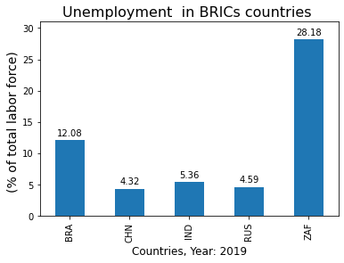

```python
def graph_col_countries (df, df_fields, input_values, year, factor):
# plot bar graph (x = countries, y = input_values)

    y_lab = df_fields.loc[input_values]['Unit']
    graph_title = df_fields.loc[input_values]['Series'] + " in BRICs countries "

    fig,ax = plt.subplots(1) # necessary to create an ax to plot labels


    data = df[df['year']==year].groupby(['country'])[input_values].mean()
    ax.plot = data.plot(kind='bar', subplots=True, figsize = (8,6))
    plt.title (graph_title, fontdict={'fontsize':16})
    plt.xlabel ('Countries, Year: %d' %year, fontsize = 12)
    plt.ylabel (y_lab, fontsize = 14)
    plt.ylim((0,data.max()*1.1))
    print (data)

    # plot labels
    for p in ax.patches:

        ax.annotate('{0:,}'.format(round((p.get_height())*factor,2)), (p.get_x() + p.get_width()/2, p.get_height()),
                    xytext=(0, 3),  textcoords="offset points", ha='center', va='bottom')

    plt.show()

graph_col_countries (df, df_fields, 'unemp', 2019, 1)
```

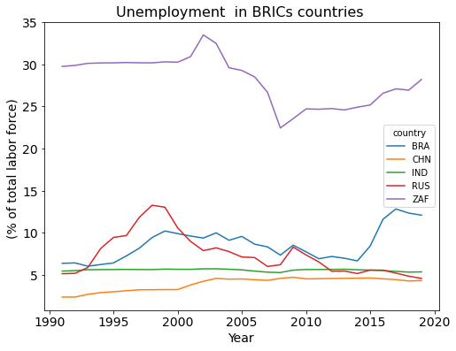

```python
def graph_line_comparative (df, df_fields, input_values):
# plot line graph (x = years, y = input_values, color = countries)

    ylabel = df_fields.loc[input_values]['Unit']
    graph_title = df_fields.loc[input_values]['Series'] + " in BRICs countries "

    df.pivot_table(values= input_values, index='year', columns='country').plot(figsize = (8,6), fontsize = 14)

    plt.title (graph_title, fontdict={'fontsize':16})
    plt.xlabel ('Year', fontsize = 14)
    plt.ylabel (ylabel, fontsize = 14)

graph_line_comparative (df, df_fields, 'unemp')
```

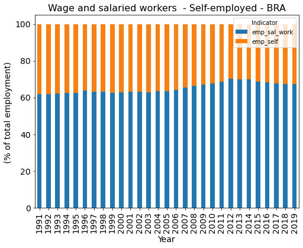

```python
def graph_bar_stacked (df, df_fields, input_country, input_values):
# plot columns stacked graph (x = years, y = input_values, color = input_values)

    y_lab = df_fields.loc[input_values[1]]['Unit']
    graph_title = str()
    for value in input_values:
        graph_title = graph_title + df_fields.loc[value]['Series'] + " - "

    df[df['country']==input_country].pivot_table(values= input_values, index='year').plot(kind= 'bar', stacked=True, figsize = (8,6), fontsize = 14)
    plt.title (graph_title + input_country, fontdict={'fontsize':16})
    plt.xlabel ('Year', fontsize = 14)
    plt.ylabel (y_lab, fontsize = 14)


graph_bar_stacked (df, df_fields, 'BRA', ('emp_sal_work', 'emp_self'))
```

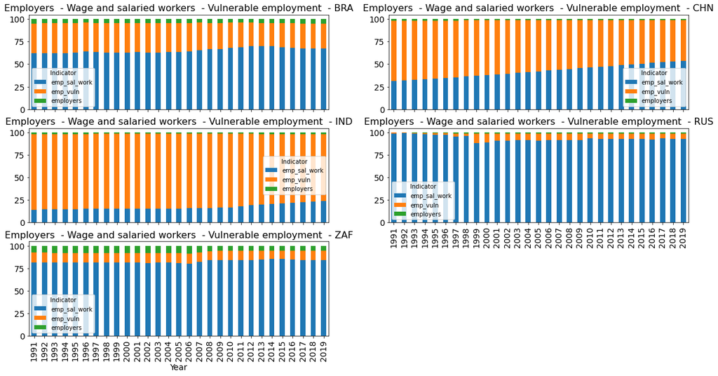

```python
def subplot_bar_stacked (df, df_fields, input_values):
# plot subplots of columns stacked graphs (x = years, y = input_values, color = input_values)

    fig, axes = plt.subplots(nrows=3, ncols=2, figsize=(20,10))
    # plt.subplots_adjust(wspace=0.2, hspace=0.8)

    i=0
    j=0
    countries = np.array(df['country'].unique())

    graph_title = str()
    for value in input_values:
        graph_title = graph_title + df_fields.loc[value]['Series'] + " - "

    for country in countries:

        df[df['country']==country].pivot_table(values= input_values, index='year').plot(ax=axes[i,j], kind = 'bar',
        stacked=True, fontsize = 14, sharex = True)

        axes[i,j].set_title (graph_title + country, fontdict={'fontsize':16})

        axes[i,j].tick_params(axis = 'y', labelleft = True, labelsize = 14)

        y_lab = df_fields.loc[input_values[1]]['Unit']
        axes[i,j].set_xlabel ('Year', fontsize = 14)


        j=j+1
        if j==2:
            i=i+1
            j=0

    axes[2,1].remove()
    axes[1,1].tick_params(axis = 'x', labelbottom = True, rotation = 90, labelsize = 14)

subplot_bar_stacked (df, df_fields, ('employers','emp_sal_work', 'emp_vuln'))
```

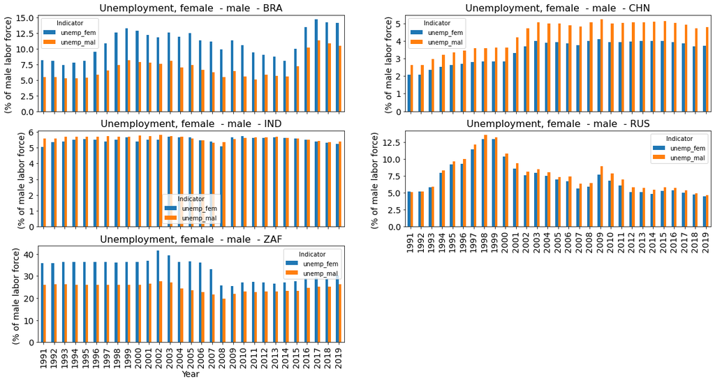

```python
def subplot_bar_dodge (df, df_fields, input_values):
# plot subplots of columns dodge graphs (x = years, y = input_values, color = input_values)

    fig, axes = plt.subplots(nrows=3, ncols=2, figsize=(20,10))
    # plt.subplots_adjust(wspace=0.2, hspace=0.8)

    i=0
    j=0
    countries = np.array(df['country'].unique())

    graph_title = str()
    for value in input_values:
        graph_title = graph_title + df_fields.loc[value]['Series'] + " - "

    for country in countries:

        df[df['country']==country].pivot_table(values= input_values, index='year').plot(ax=axes[i,j], kind = 'bar',
        stacked=False, fontsize = 14, sharex = True)

        axes[i,j].set_title (graph_title + country, fontdict={'fontsize':16})

        y_lab = df_fields.loc[input_values[1]]['Unit']
        axes[i,j].set_ylabel (y_lab, fontsize = 14)
        axes[i,j].set_xlabel ('Year', fontsize = 14)


        j=j+1
        if j==2:
            i=i+1
            j=0

    axes[2,1].remove()
    axes[1,1].tick_params(axis = 'x', labelbottom = True, rotation = 90, labelsize = 14)

subplot_bar_dodge (df, df_fields, ('unemp_fem','unemp_mal'))
```

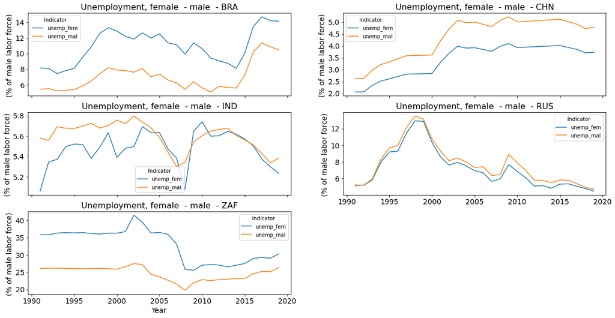

```python
def subplot_line (df, df_fields, input_values):
# plot subplots of line graphs (x = years, y = input_values, color = input_values)

    fig, axes = plt.subplots(nrows=3, ncols=2, figsize=(20,10))
    # plt.subplots_adjust(wspace=0.2, hspace=0.8)

    i=0
    j=0
    countries = np.array(df['country'].unique())

    graph_title = str()
    for value in input_values:
        graph_title = graph_title + df_fields.loc[value]['Series'] + " - "

    for country in countries:


            df[df['country']==country].pivot_table(values= input_values, index='year').plot(ax=axes[i,j], kind = 'line',
            stacked=False, fontsize = 14, sharex = True)

            axes[i,j].set_title (graph_title + country, fontdict={'fontsize':16})
            ylabel = df_fields.loc[input_values[1]]['Unit']
            axes[i,j].set_ylabel (ylabel, fontsize = 14)
            axes[i,j].set_xlabel ('Year', fontsize = 14)


            j=j+1
            if j==2:
                i=i+1
                j=0


    axes[2,1].remove()
    axes[1,1].tick_params(labelbottom = True, labelsize = 14) #rotation=90

subplot_line (df, df_fields, ('unemp_fem','unemp_mal'))
```

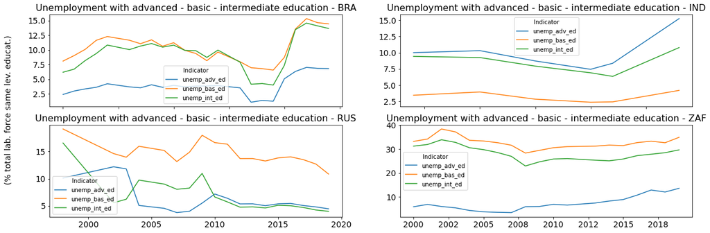

```python
def subplot_line_nan (df, df_fields, input_values):
# plot subplots of line graphs, when there are countries with only nan values
# (x = years, y = input_values, color = input_values)


    fig, axes = plt.subplots(nrows=3, ncols=2, figsize=(20,10))
    # plt.subplots_adjust(wspace=0.2, hspace=0.8)

    i=0
    j=0
    count=0
    countries = np.array(df['country'].unique())

    graph_title = str()
    for value in input_values:
        graph_title = graph_title + df_fields.loc[value]['Series'] + " - "

    for country in countries:

            df1=df[df['country']==country].pivot_table(values= input_values, index='year')

            if df1.empty == False:

                df1.plot(ax=axes[i,j], kind = 'line',
                stacked=False, fontsize = 14, sharex = True)

                axes[i,j].set_title (graph_title + country, fontdict={'fontsize':16})
                #ylabel = df_fields.loc[input_values[1]]['Unit']
                #axes[i,j].set_ylabel (ylabel, fontsize = 14)
                axes[i,j].set_xlabel ('Year', fontsize = 14)

                j=j+1
                if j==2:
                    i=i+1
                    j=0
            else:
                count=count+1

    y_lab = df_fields.loc[input_values[1]]['Unit']
    fig.text(0.07, 0.65, y_lab, va='center', rotation='vertical', fontsize = 14)

    #for c in count:
    axes[2,1].remove()
    axes[2,0].remove()
    axes[1,0].tick_params(labelbottom = True, labelsize = 14) #rotation=90
    axes[1,1].tick_params(labelbottom = True, labelsize = 14) #rotation=90

    axes[1,1].xaxis.set_major_formatter(FormatStrFormatter('%.0f'))


subplot_line_nan (df, df_fields, ('unemp_adv_ed','unemp_bas_ed','unemp_int_ed'))
```

# Summary overview

## Economy

**GDP**

```
country
BRA    1.839758e+12
CHN    1.434290e+13
IND    2.875142e+12
RUS    1.699877e+12
ZAF    3.514316e+11
Name: gdp, dtype: float64
```

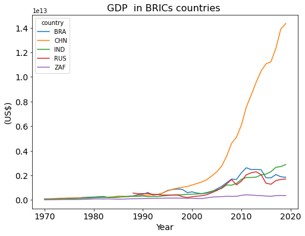

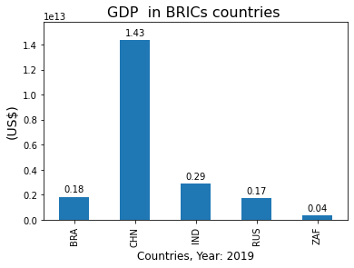

```python
graph_line_comparative (df, df_fields, 'gdp')
graph_col_countries (df, df_fields, 'gdp', 2019, 1/1e13)
```

Comments:

**GDP per capita**

```
country
BRA     9925.386238
CHN     8879.438149
IND     1981.651050
RUS    10720.332585
ZAF     6132.479841
Name: gdp_cap, dtype: float64
```

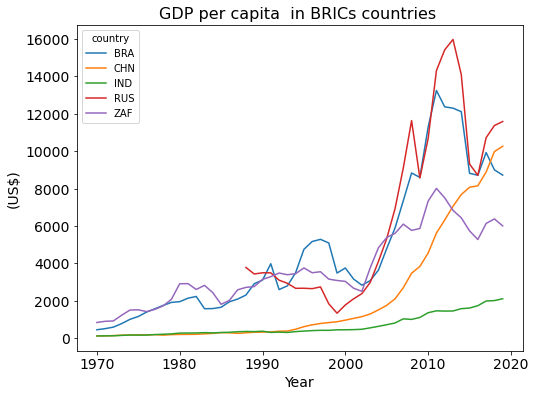

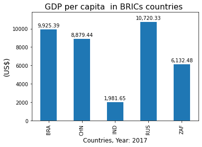

```python
graph_line_comparative (df, df_fields, 'gdp_cap')
graph_col_countries (df, df_fields, 'gdp_cap', 2017, 1)
```

Comments:

- Despite the rapid growth of GDP in China, Russia has a higher GDP per capita.
- Brazil and Russia had a relatively similar curve behaviour after mid-2000. However, the values in Brazil were lower than in Russia in this period.
- After 2018, China becomes the second country with the highest GDP per capita among the BRICS countries.
- South Africa has a GDP per capita higher than India. The latter is the country of the BRICS with the lowest GDP per capita.

**GDP by sector**

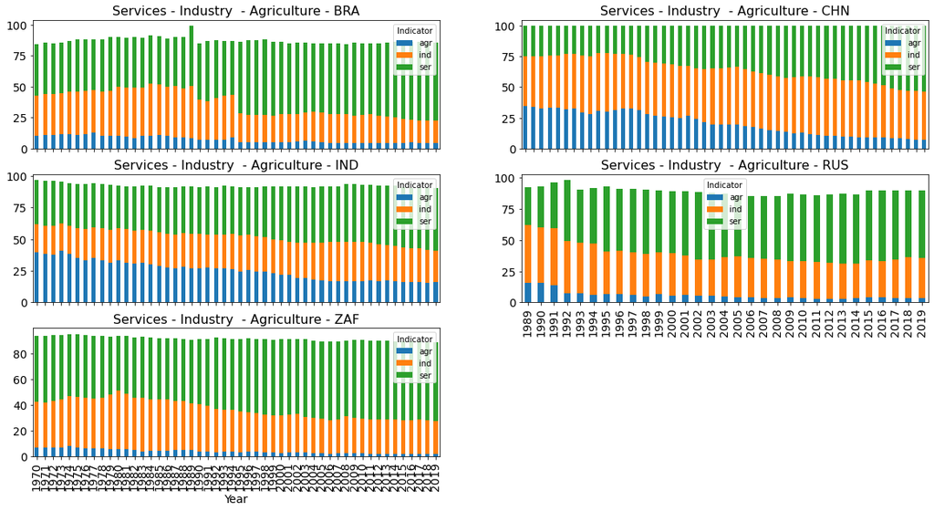

```python
subplot_bar_stacked (df, df_fields, ('ser', 'ind', 'agr'))
```

```
country
BRA     4.436545
CHN     7.111634
IND    15.964598
RUS     3.448292
ZAF     1.884542
Name: agr, dtype: float64
```

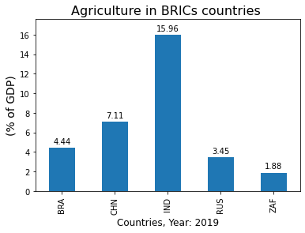

```
country
BRA    17.922226
CHN    38.972540
IND    24.881008
RUS    32.166303
ZAF    25.999222
Name: ind, dtype: float64
```

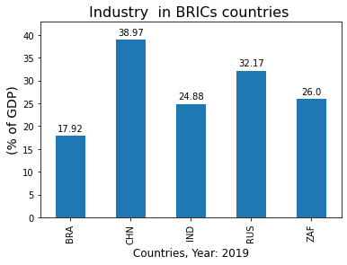

```python
graph_col_countries (df, df_fields, 'agr', 2019, 1)
graph_col_countries (df, df_fields, 'ind', 2019, 1)
```

Comments:

- In all countries, the percentage of agriculture in GDP has decreased over the years and the percentage of services has increased.
- India is the country with the largest share of agriculture in GDP compared to the BRICS countries (16%), followed by China (7%).
- In industry, China is the country with the largest share in GDP compared to the BRICS countries (39%), followed by Russia (32%).

Supplementary notes: The source does not provide any information regarding percentage points not adding up to or exceeding 100 percent.

## Population

**Urban x Rural**

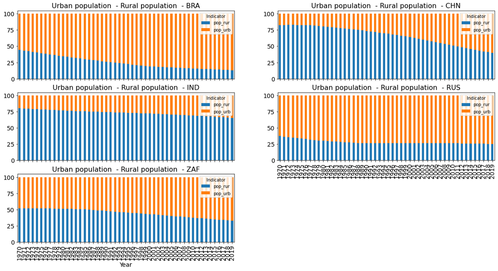

```python
subplot_bar_stacked (df, df_fields, ('pop_urb', 'pop_rur'))
```

```
country
BRA    13.176
CHN    39.692
IND    65.528
RUS    25.413
ZAF    33.144
Name: pop_rur, dtype: float64
```

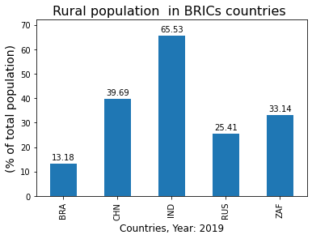

```python
graph_col_countries (df, df_fields, 'pop_rur', 2019, 1)
```

Comments:

- In all countries, the percentage of rural population has decreased over the years.
- India is the only country in the BRICS that has more participation of rural than urban population (65%).
- The second and third countries with more rural participation are China (39%) and South Africa (33%).

## Employment

**Employment by sector**

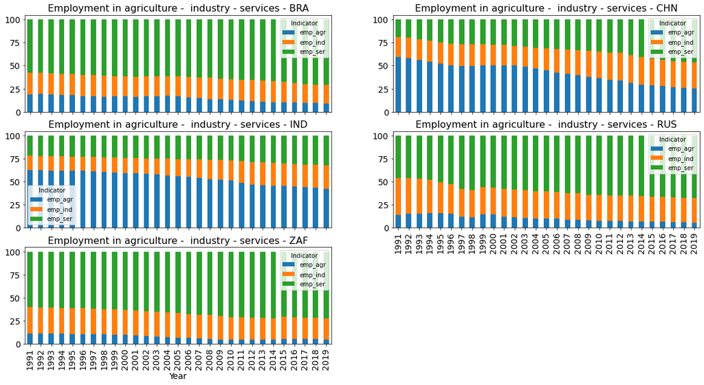

```python
subplot_bar_stacked (df, df_fields, ('emp_agr','emp_ind','emp_ser'))
```

```
country
BRA     9.221000
CHN    25.363001
IND    42.384998
RUS     5.757000
ZAF     5.088000
Name: emp_agr, dtype: float64
```

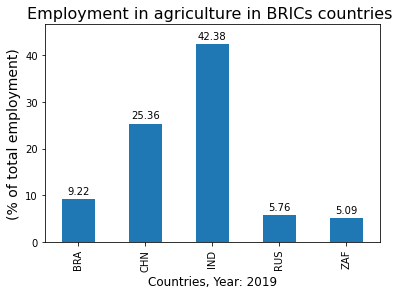

```python
graph_col_countries (df, df_fields, 'emp_agr', 2019, 1)
```

Comments:

- Although agriculture contributes only 16% in India’s GDP, it contributes 42% in India's employment.
- The same pattern happens with China. Although agriculture contributes only 7% in China’s GDP, it contributes 25% in China's employment.

**Self employed x Wage and salaried workes**

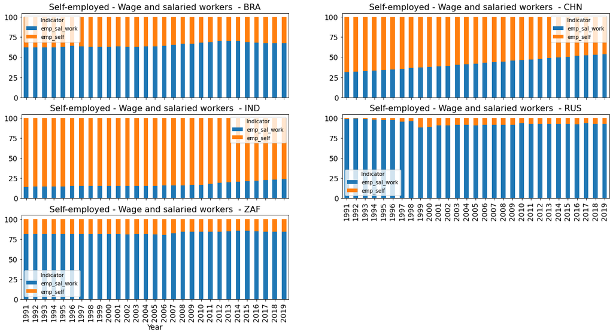

```python
subplot_bar_stacked (df, df_fields, ('emp_self','emp_sal_work'))
```

```
country
BRA    32.710999
CHN    46.748001
IND    76.285004
RUS     6.790000
ZAF    15.552000
Name: emp_self, dtype: float64
```

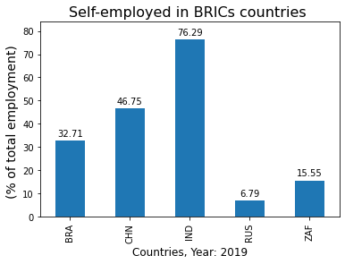

```python
graph_col_countries (df, df_fields, 'emp_self', 2019, 1)
```

Comments:

- In India, approximately 76% of total employment are self-employed; in China, 47%. On the other hand, the percentage of wage and salaried workers in these countries are continually increasing, mainly in China.
- In South Africa and Russia the percentage of salaried workers is high, approximately or above 80%.

**Vulnerable employment**

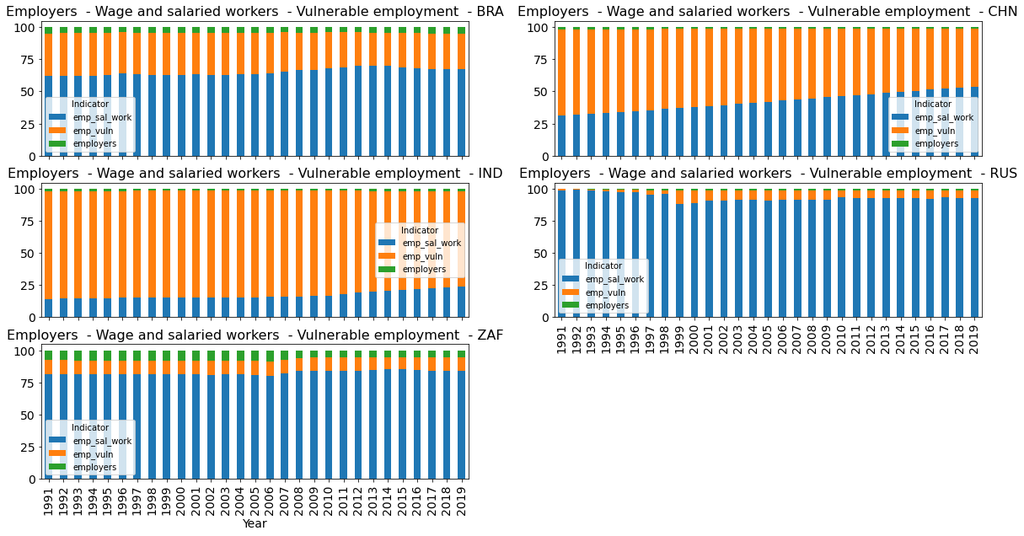

```python
subplot_bar_stacked (df, df_fields, ('employers','emp_sal_work', 'emp_vuln'))
```

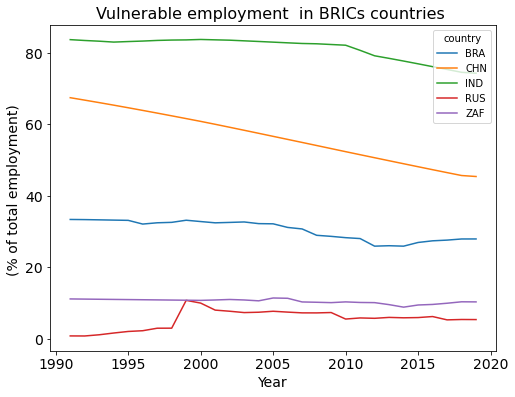

```python
graph_line_comparative (df, df_fields, 'emp_vuln')
```

```
country
BRA    27.908000
CHN    45.377999
IND    74.269999
RUS     5.350000
ZAF    10.298000
Name: emp_vuln, dtype: float64
```

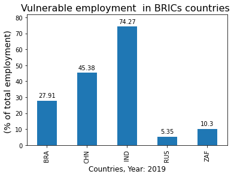

```python
graph_col_countries (df, df_fields, 'emp_vuln', 2019, 1)
```

Comments:

- India and China are the countries with more vulnerable work, 74% and 45%, respectively.
- In the last years the percentage of vulnerable work has reduced in these 2 countries.

**Unemployment**

```
country
BRA    12.083
CHN     4.320
IND     5.355
RUS     4.585
ZAF    28.181
Name: unemp, dtype: float64
```

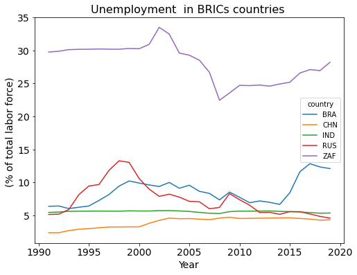

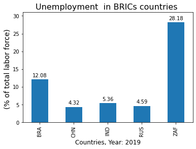

```python
graph_line_comparative (df, df_fields, 'unemp')
graph_col_countries (df, df_fields, 'unemp', 2019, 1)
```

UR (%) = Persons unemployed/Labour force x 100 Labour force = Persons employed + persons unemployed

Comments:

Supplementary note: Regarding the international comparability of unemployment rates, there are some differences in their measurements, which can affect the comparability of results across countries.

**Unemployment by level of education**

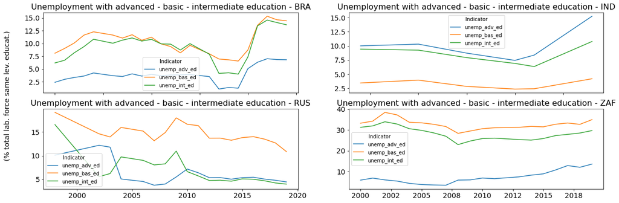

```python
subplot_line_nan (df, df_fields, ('unemp_adv_ed','unemp_bas_ed','unemp_int_ed'))
```

Unemployment with:

- advanced education (% of labour force unemployed with advanced education/ % of total labour force with advanced education)
- intermediate education (% of labour force unemployed with intermediate education/ % of total labour force with intermediate education)
- basic education (% of labour force unemployed with basic education/ % of total labour force with basic education)

Comments:

- In India the unemployment rate for people with advanced education is higher than for those with intermediate and basic education.
- There is no data for China.

**Unemployment by gender**

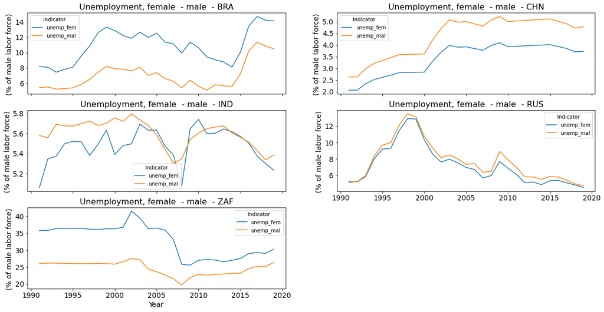

```python
subplot_line (df, df_fields, ('unemp_fem','unemp_mal'))
```

- male unemployment (% of male labor force)
- female unemployment (% of female labor force)

Comments:

- There is more female unemployment than male unemployment in Brazil and in South Africa.
- In China, there is more male unemployment.
- The unemployment between genders in Russia occurs in a balanced way.
- In India is relatively balanced for almost 10 years.

It is important to evaluate how is the proportion of the female labour force in relation to the total population in other countries (see below).

**Labour force participation rate by gender**

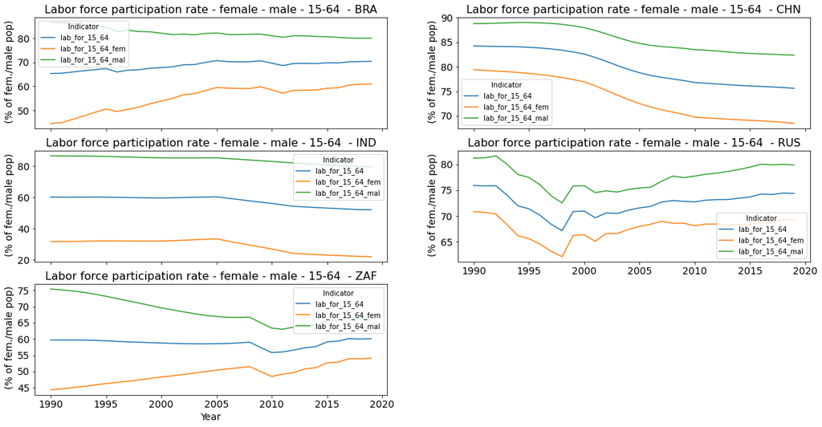

```python
subplot_line (df, df_fields, ('lab_for_15_64_fem','lab_for_15_64_mal', 'lab_for_15_64'))
```

lab_for_15_64_fem: (% of female population ages 15-64)  
lab_for_15_64_mal: (% of male population ages 15-64)  
lab_for_15_64: (% of population ages 15-64)

Comments:

- In India the percentage of female labour force is relative low compared to other countries.
- The percentage of female labour force in China and Russia is higher than Brazil and South Africa.

**Unemployment by age**

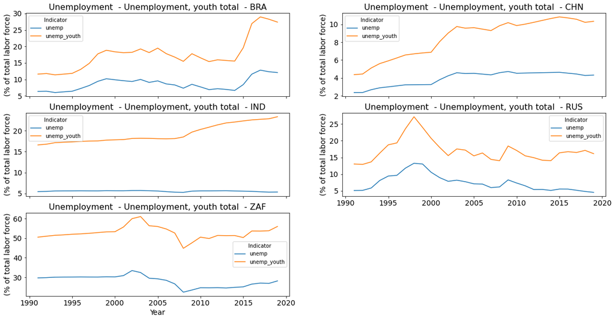

```python
subplot_line (df, df_fields, ('unemp','unemp_youth'))
```

Comments:

- The youth unemployment is above the unemployment rate in all BRICS countries

**Labour force participation rate by age**

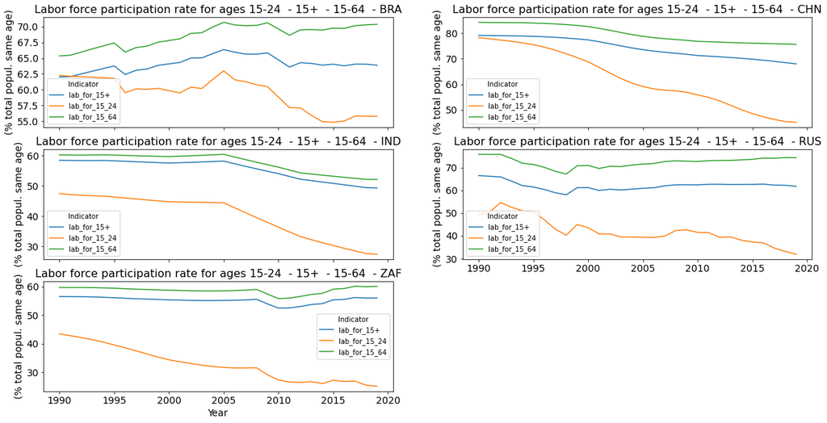

```python
subplot_line (df, df_fields, ('lab_for_15_24','lab_for_15+', 'lab_for_15_64'))
```

LFPR(%) = Labour force/Working-age population x 100 Labour force = Persons employed + persons unemployed

Comments:

- In all BRICS countries the percentage of total labor force ages 15-24 has significantly decreased in the last 30 years.

# Correlations between the indicators

Analyze the unemployment and the socio-economic indicators most related to it.

```python
# Selecting the features for regression analysis.
# Eliminating features that are redundant or not relevant at first (e.g keeping "GDP per capita" instead of GDP).
    # keeping the main indicator, excluding the same indicator classified by gender and age.
    # keeping only one indicator, when the other is complementary (e.g. population rural x urban)
    # eliminating the indicators related to unemployment (unemployment with advanced, intermediate and basic education)

exclude = df_fields[df_fields['Regression']=='no'].index.values # columns names to not consider in the regression

df.columns
df_reg = df.drop(columns = exclude)

df_reg.info()
```

```
<class 'pandas.core.frame.DataFrame'>
RangeIndex: 250 entries, 0 to 249
Data columns (total 33 columns):
 #   Column          Non-Null Count  Dtype
---  ------          --------------  -----
 0   country         250 non-null    object
 1   year            250 non-null    int32
 2   agr             231 non-null    float64
 3   emp_child       14 non-null     float64
 4   emp_inf         29 non-null     float64
 5   emp_self        145 non-null    float64
 6   emp_vuln        145 non-null    float64
 7   employers       145 non-null    float64
 8   exp_edu         97 non-null     float64
 9   exp_goods       231 non-null    float64
```

[output cut: 25 more lines]

Performe feature analysis, to determine the most influential features, eliminate redundant, or less relevant ones.

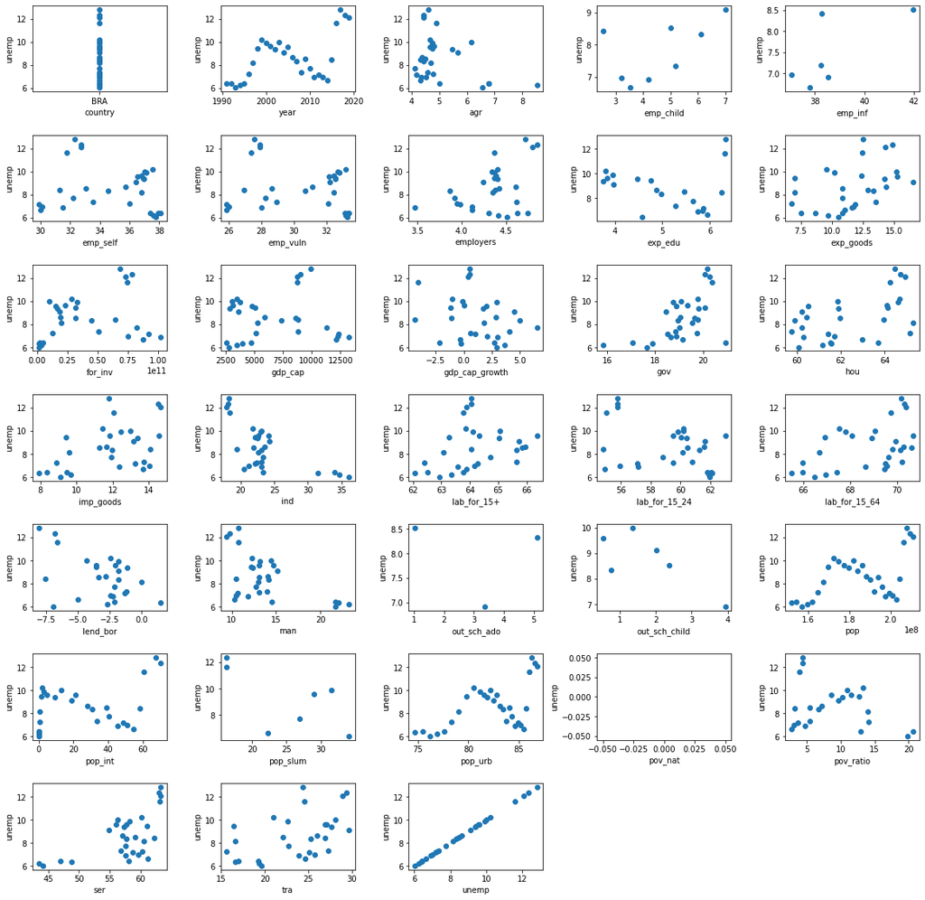

```python
# Analysing the data for each country

def plot_correlations (df):
# Plotting graphics with correlations among the columns for a specific country - Subplots

    r= ceil(len(df.columns)/5)

    # for col_y in df.columns:
    col_y = 'unemp'
    fig = plt.figure(figsize=(20,20))
    fig.subplots_adjust(hspace=0.5, wspace=0.4)
    i = 1
    for col_x in df.columns:
        ax = fig.add_subplot(r, 5, i)
        ax.scatter (df[col_x].values, df[col_y].values)
        ax.set(xlabel = col_x, ylabel =col_y)
        i = i+1

#plt.rcParams.update({'figure.max_open_warning': 0})
plot_correlations (df_reg[df_reg['country'] == 'BRA'])
```

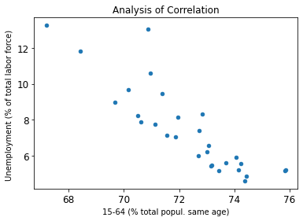

```python
def plot_correlations_variables (df, col_x, col_y):
# Plotting one graphic with the correlation between 2 indicators for a specific country

            df.plot(x=col_x, y=col_y, kind='scatter',title='Analysis of Correlation',fontsize=12)
            if (col_x!='year') and (col_x!='country'):
                plt.xlabel (df_fields.loc[col_x,'Series']+df_fields.loc[col_x,'Unit'])
            if (col_y!='year') and (col_y!='country'):
                    plt.ylabel (df_fields.loc[col_y,'Series']+df_fields.loc[col_y,'Unit'])
            plt.show()

plot_correlations_variables (df_reg[df_reg['country'] == 'RUS'], 'lab_for_15_64', 'unemp')
```

```python
def plot_correlations_detailed (df):
# Plotting graphics with correlations among the columns for a specific country

    for col_y in df.columns:
        for col_x in df.columns:
            df.plot(x=col_x, y=col_y, kind='scatter',title='Analysis of Correlation',fontsize=12)
            if (col_x!='year') and (col_x!='country'):
                plt.xlabel (df_fields.loc[col_x,'Series']+df_fields.loc[col_x,'Unit'])
            if (col_y!='year') and (col_y!='country'):
                    plt.ylabel (df_fields.loc[col_y,'Series']+df_fields.loc[col_y,'Unit'])
            plt.show()
```

```python
# plot_correlations_detailed (df_reg[df_reg['country'] == 'BRA'])
```

**Best features**

```python
# we will create a database for each country to compute the best features and to do the regressions

C = np.array(df_reg['country'].unique()) # array of BRICs countries
df_c={} # creating a data frame for each country
col_few_data = []


for i, index in enumerate(C):

    df_c[i] = df_reg[df_reg.country==C[i]] # creating a data frame for each country
    df_c[i] = df_c[i][df_c[i]['unemp'].notnull()] # As we are analyzing the indicator of unemployment,
                                                  # we will select only the years where this variable is computated

    perc_nan = df_c[i].isnull().sum(axis = 0)/len(df_c[i])

    to_exclude = perc_nan[perc_nan>0.25].index.tolist() # considering columns with 75% of not null,
                                                        # dropping collumns with more than 25% of null

    print(perc_nan[perc_nan>0.25])  # command to see the summary of columns to be excluded in each country
    col_few_data = col_few_data + to_exclude

# as we want to consider the same features in the analysis for all countries
# we will remove the columns from all country data frames. Also the columns
# to be excluded are very similar among the countries.

col_few_data = set(col_few_data) # eliminating repeated data
print(col_few_data) # print columns excluded

for i, index in enumerate(C):
    df_c[i] = df_c[i].drop(columns = col_few_data) # drop the columns

# df_c[i] = df_c[i].dropna(axis=1, how='all')   # drop columns without any data (only with NAN) -
                                                # I didn't need this command, but I want to save it
# pd.set_option('display.max_columns', None)
# df_c[0]

# Handling missing values
# To compute the best features, we need to fill the nan values that still remained

df_c_fill={}
y={}
X={}

for i, index in enumerate(C):
    df_c_fill [i] = df_c[i]
    df_c_fill [i] = df_c_fill [i].fillna(method='ffill')
    df_c_fill [i] = df_c_fill [i].fillna(method='bfill')
    if i==3:
        df_c_fill [3] = df_c_fill[3].drop(columns = 'lab_for_15+')
        # excluding this option after analysing the results (redundant)
    y [i] = df_c_fill [i]['unemp']
    X [i] = df_c_fill [i].iloc[:,2:-1]
    #print(x[i])
```

```
Indicator
emp_child        0.724138
emp_inf          0.793103
exp_edu          0.310345
out_sch_ado      0.896552
out_sch_child    0.793103
pop_slum         0.758621
pov_nat          1.000000
dtype: float64
Indicator
emp_child        1.000000
emp_inf          1.000000
exp_edu          0.758621
lend_bor         1.000000
man              0.448276
out_sch_ado      1.000000
out_sch_child    0.758621
pop_slum         0.793103
pov_nat          0.586207
pov_ratio        0.551724
dtype: float64
Indicator
emp_child        0.827586
emp_inf          0.896552
exp_edu          0.551724
out_sch_ado      0.965517
out_sch_child    0.620690
pop_slum         0.758621
pov_nat          0.862069
pov_ratio        0.862069
dtype: float64
Indicator
emp_child        1.000000
emp_inf          1.000000
exp_edu          0.517241
man              0.379310
out_sch_ado      0.793103
out_sch_child    0.517241
pop_slum         1.000000
pov_nat          0.379310
dtype: float64
Indicator
emp_child        0.965517
emp_inf          0.310345
exp_edu          0.275862
out_sch_ado      0.655172
out_sch_child    0.517241
pop_slum         0.758621
pov_nat          0.862069
pov_ratio        0.758621
dtype: float64
{'out_sch_child', 'pov_nat', 'man', 'out_sch_ado', 'exp_edu', 'emp_inf', 'pop_slum', 'pov_ratio', 'lend_bor', 'emp_child'}
```